# When is it snacky snacky time for you?

The data was collected using a Google Form survey, which I shared with my family and friends to gain insight into eating and snacking habits during the work week. This helped provide a clearer picture of the snacking behaviours of those closest to me. From the responses, I was able to explore the frequency of snacking between AM and PM, the consumption of liquid snacks throughout the day, the maximum price people are willing to spend on solid versus liquid snacks, and the most common hours solid foods are consumed.

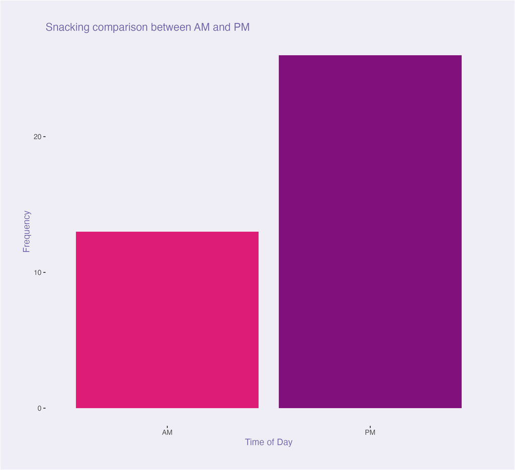

Comparison of snacking between AM and PM

The graph shows a clear visual comparison between the two times of day when snacking can occur. From this, we can see that snacking happens more often during the PM compared to the AM. This makes sense, as most of the survey participants were students who often stay up late studying or cramming for exams.

Ahhh, cramming… I’m so over it!

## Distribution of liquid snacks during the time of day

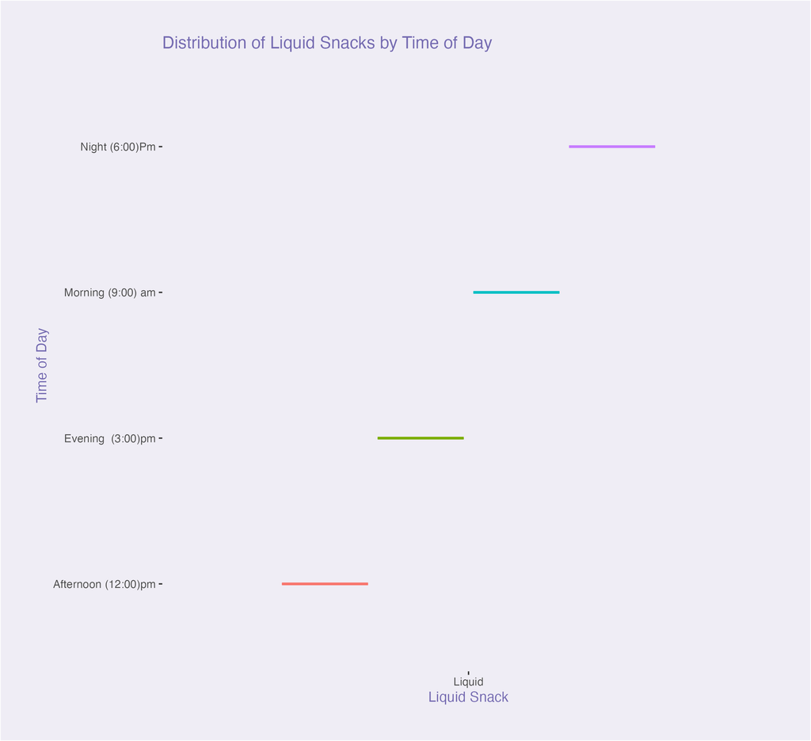

Distribution of liquid snacks during the time of day

## Comaprison between solid and liquid snacks.

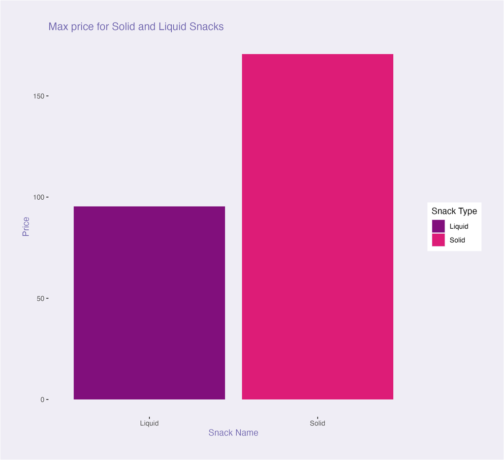

## Which hour of the day do we eat solid snacks

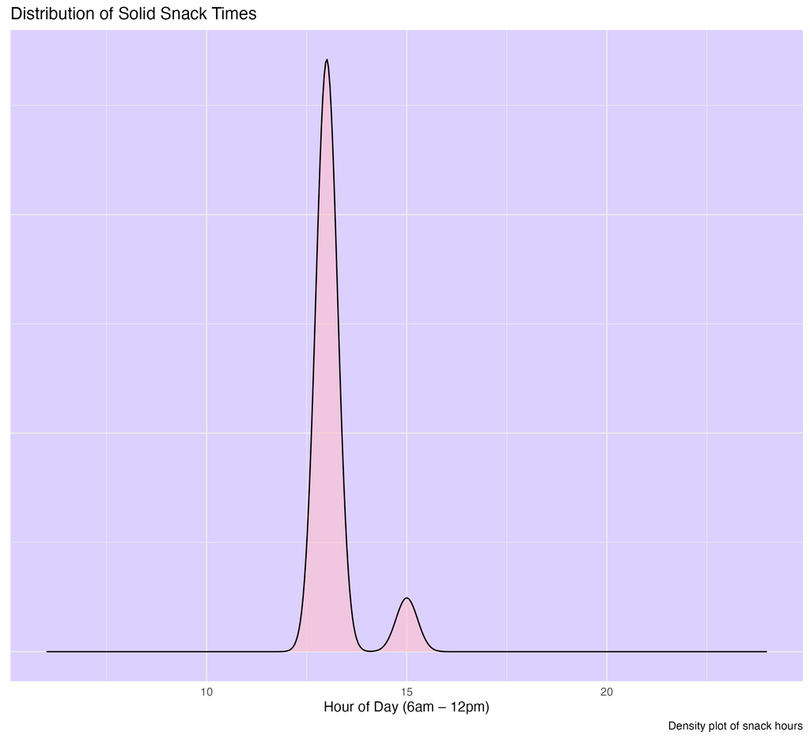

Which hour of the day do we eat solid snacks

There seems to be a large spike for solid snacks during afternoon time, this would be because naturally you get hungry around then after studying or doing work for long periods of time, or would enjoy a snack around lunch time. Outside of this data point this is seen durin the rush lunch hoour.

## what did i learn from this

I now have a better understanding of the relationship I have with food and the times I tend to eat. It turns out I’m more of a snacker than I thought, and through my graphs, I was able to identify clear patterns and habits in my eating behaviour. Since this survey was also completed by other students, it reflects how our study or work schedules influence when and how we eat.

[figure not shown]

photo